# Final Project

Anay Athawale

2023-08-07

```r
#loading necessary packages
library(tidyverse)
library(psych)
library(GGally)
```

```r
library(ggplot2)
library(ggExtra)
library(gmodels)
library(caret)
library(fastDummies)
library(e1071)
library(randomForest)
library(corrplot)
library(dplyr)
library(class)
```

////PHASE ONE : BUSINESS UNDERSTANDING This phase delves deep into comprehending the project from a healthcare perspective and formulating a strategy to meet the objectives.

//Determining the business objectives This phase seeks to unearth the primary business objective. I am a Bioinformatics Student focusing on the growing epidemic of diabetes. Recognizing the global prevalence of diabetes, especially among Pima Indians, I became intrigued about predicting the likelihood of its occurrence based on health-related metrics. To assist healthcare professionals and individuals in assessing diabetes risk, I have decided to employ the Machine Learning and Data mining techniques acquired during this course.

The primary aim is to harness Machine Learning and Data mining techniques to anticipate the likelihood of diabetes based on specific health parameters.

//Situation assessment This phase addresses the available data to achieve the primary business goal and lists potential risks along with strategies to mitigate them. The dataset includes health metrics such as glucose levels, BMI, and age. A challenge might arise due to the personal nature of the Diabetes Pedigree Function, as its interpretation might vary among individuals. Nonetheless, the core objective remains the same: predicting diabetes across diverse populations.

//Determining the data mining goals The primary data mining objective of this project is to forecast diabetes in new data entries while optimizing the predictive accuracy of various machine learning models.

////PHASE TWO : DATA UNDERSTANDING This phase encompasses data procurement, exploration, data quality evaluation, insights discovery, and the identification of noteworthy subsets to develop hypotheses.

//Collecting the data The data has been sourced from this link: https://www.kaggle.com/datasets/uciml/pima-indians-diabetes-database. The dataset, originally the Pima Indians Diabetes Database from Kaggle, offers comprehensive information on health metrics pivotal to predicting diabetes.

//Describe the data This section portrays the dataset’s structure, record count, features, and format. The obtained dataset is in CSV format, consisting of 768 entries and 8 distinct health-related features. The variables are primarily numerical, encompassing: a) Pregnancies b) Glucose c) Blood Pressure d) Skin Thickness e) Insulin f) BMI g) Diabetes Pedigree Function h) Age i) Outcome (binary: 0 or 1, indicating the absence or presence of diabetes respectively).

```r
# Loading the Pima Indians Diabetes Database into R environment
diabetes_data <- read.csv("https://raw.githubusercontent.com/anay27/FInal-Project/main/diabetes.csv")
str(diabetes_data)
```

```
## 'data.frame':    768 obs. of  9 variables:
##  $ Pregnancies             : int  6 1 8 1 0 5 3 10 2 8 ...
##  $ Glucose                 : int  148 85 183 89 137 116 78 115 197 125 ...
##  $ BloodPressure           : int  72 66 64 66 40 74 50 0 70 96 ...
##  $ SkinThickness           : int  35 29 0 23 35 0 32 0 45 0 ...
##  $ Insulin                 : int  0 0 0 94 168 0 88 0 543 0 ...
##  $ BMI                     : num  33.6 26.6 23.3 28.1 43.1 25.6 31 35.3 30.5 0 ...
##  $ DiabetesPedigreeFunction: num  0.627 0.351 0.672 0.167 2.288 ...
##  $ Age                     : int  50 31 32 21 33 30 26 29 53 54 ...
##  $ Outcome                 : int  1 0 1 0 1 0 1 0 1 1 ...
```

//Exploring the data Visualization and exploration of the data are essential in this phase. Several graphs have been crafted to delve deeper into the dataset, to identify outliers, and to assess the normal distribution of each variable.

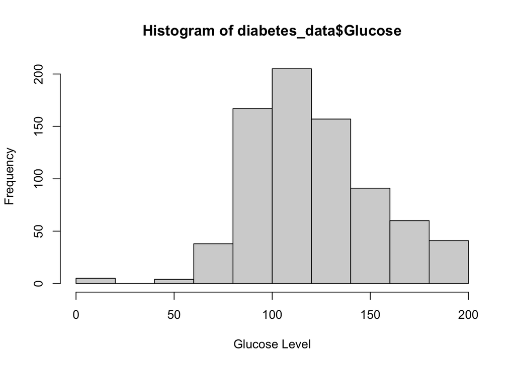

```r
# Histograms to check the normal distribution
hist(diabetes_data$Glucose, xlab = "Glucose Level")
```

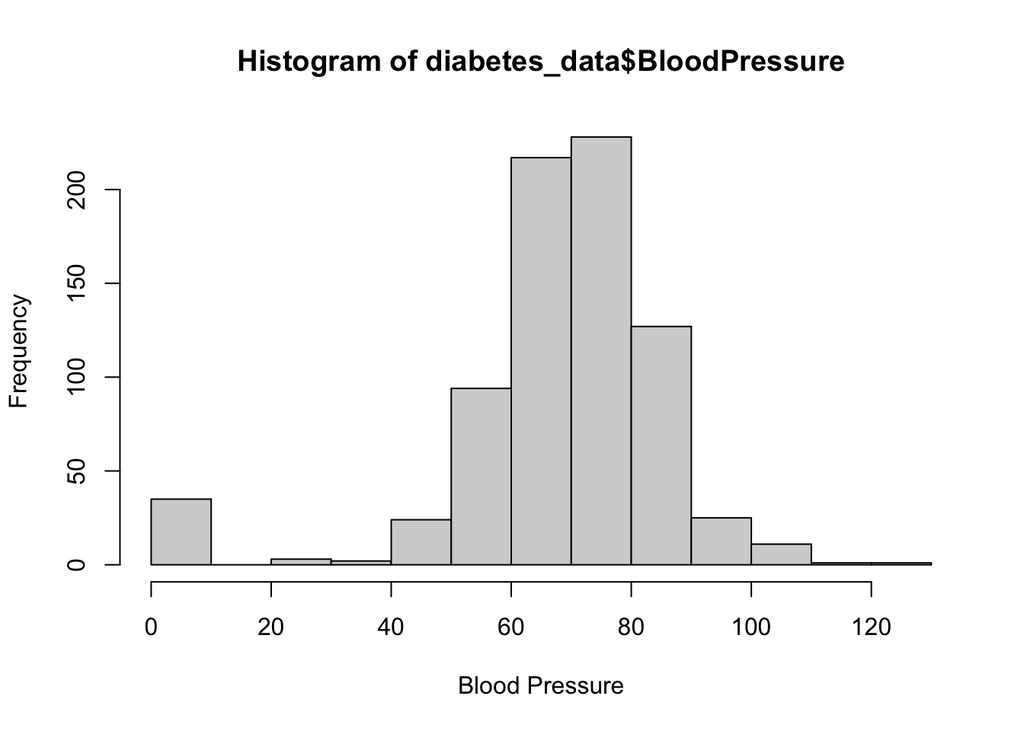

```r
hist(diabetes_data$BloodPressure, xlab = "Blood Pressure")
```

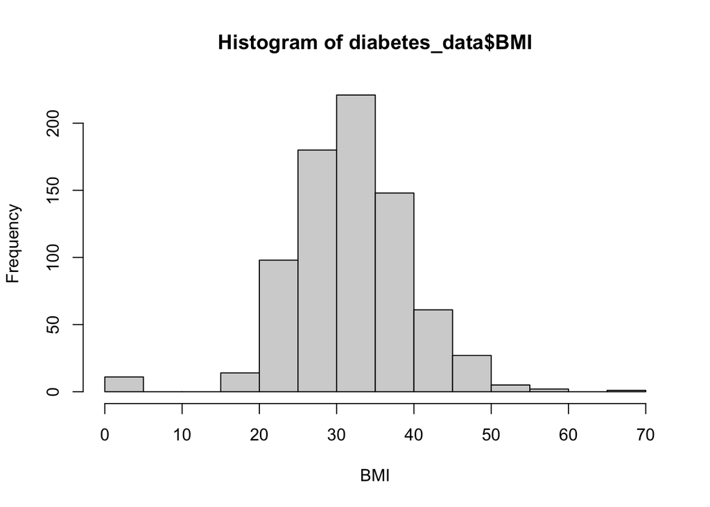

```r
hist(diabetes_data$BMI, xlab = "BMI")
```

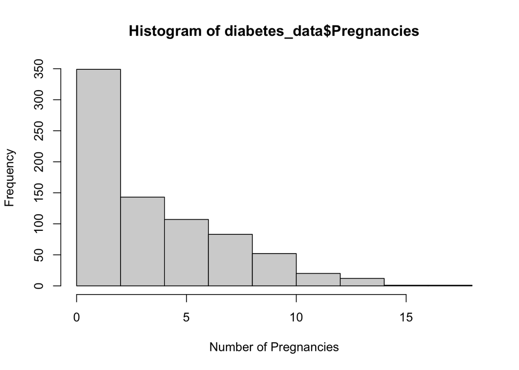

```r
hist(diabetes_data$Pregnancies, xlab = "Number of Pregnancies")
```

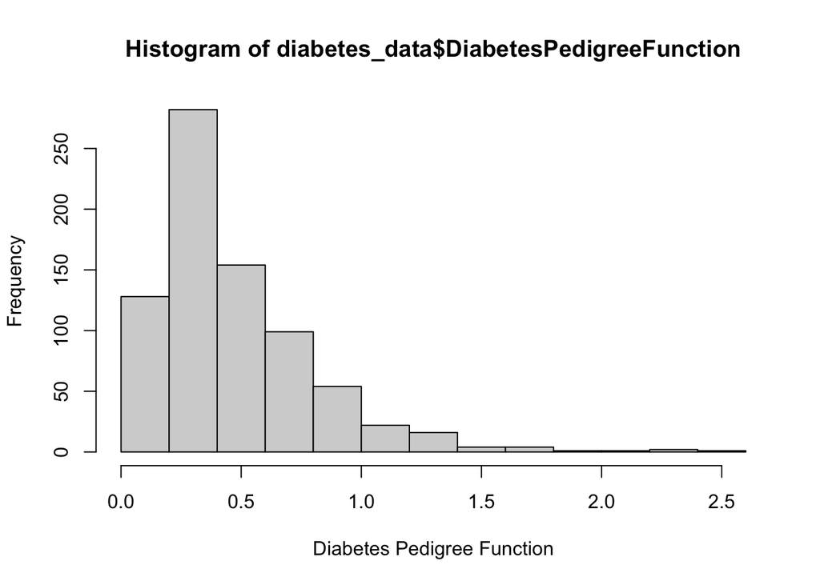

```r
hist(diabetes_data$DiabetesPedigreeFunction, xlab = "Diabetes Pedigree Function")
```

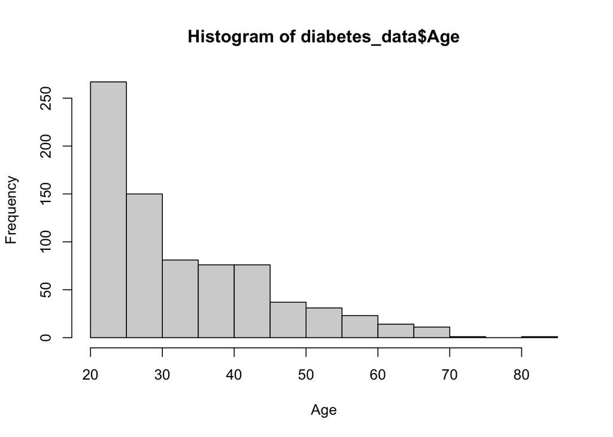

```r
hist(diabetes_data$Age, xlab = "Age")
```

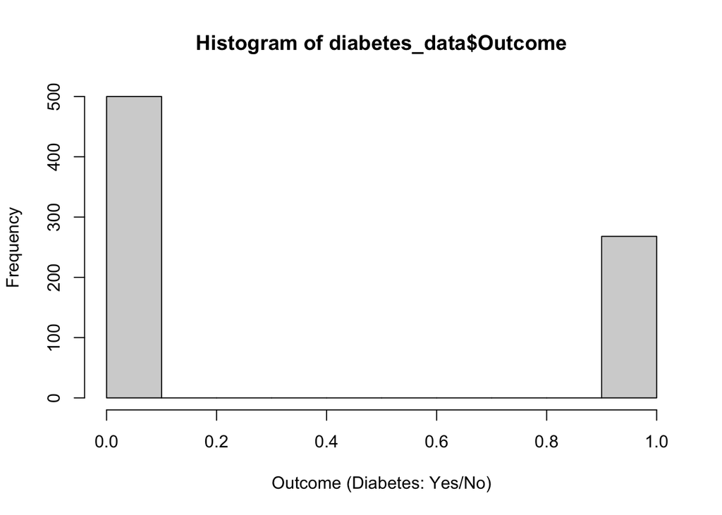

```r
hist(diabetes_data$Outcome, xlab = "Outcome (Diabetes: Yes/No)")
```

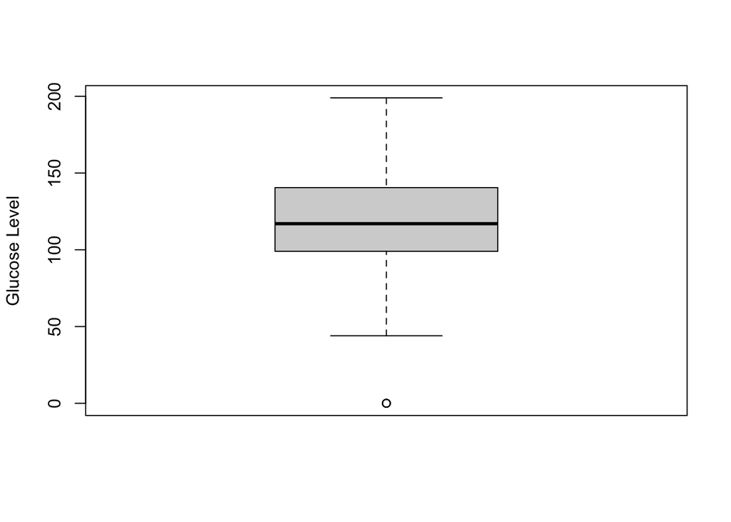

```r
# Boxplots to detect outliers
boxplot(diabetes_data$Glucose, ylab = "Glucose Level")
```

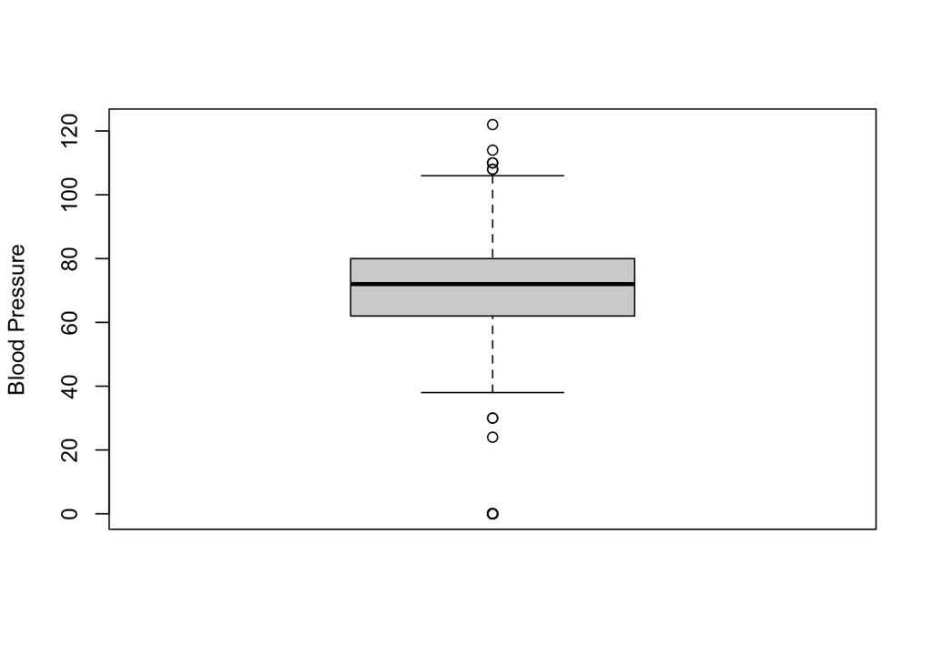

```r
boxplot(diabetes_data$BloodPressure, ylab = "Blood Pressure")
```

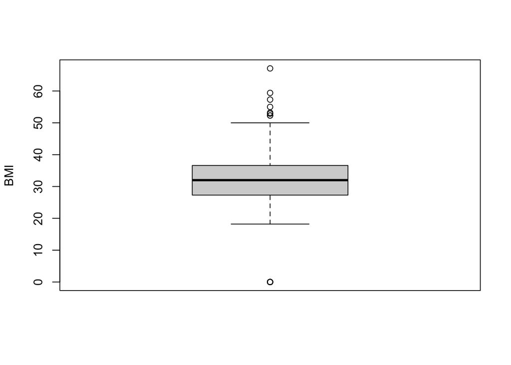

```r
boxplot(diabetes_data$BMI, ylab = "BMI")
```

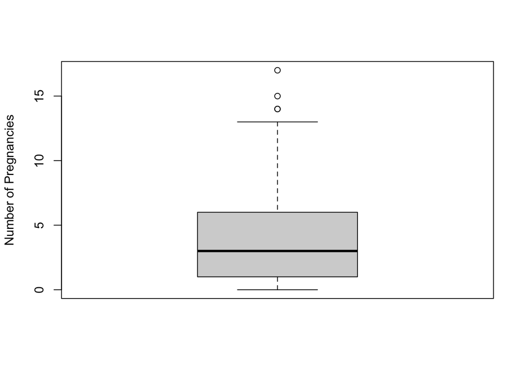

```r
boxplot(diabetes_data$Pregnancies, ylab = "Number of Pregnancies")
```

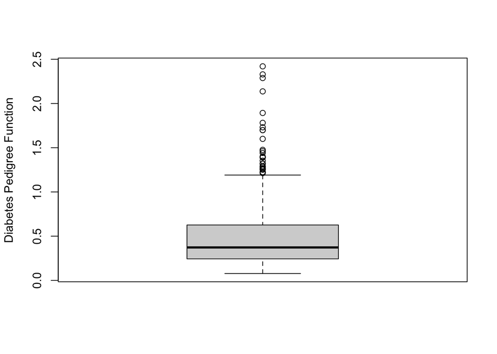

```r
boxplot(diabetes_data$DiabetesPedigreeFunction, ylab = "Diabetes Pedigree Function")
```

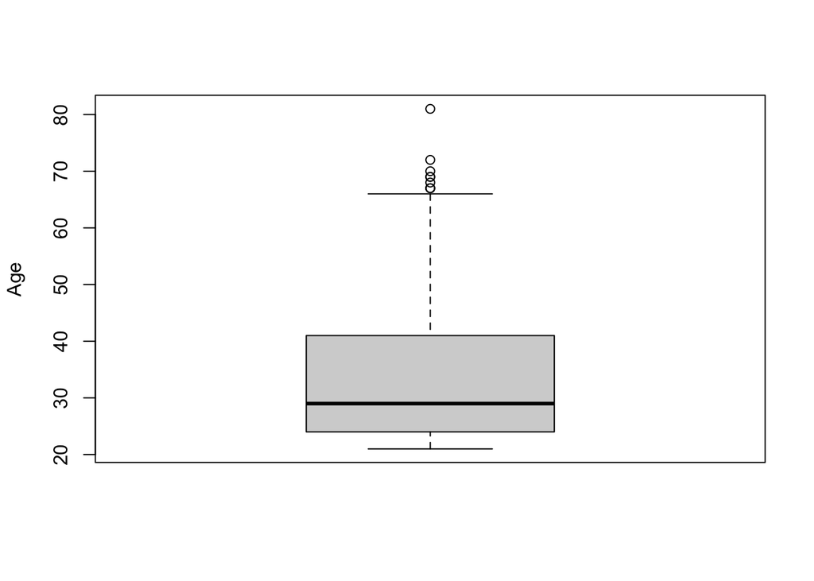

```r
boxplot(diabetes_data$Age, ylab = "Age")
```

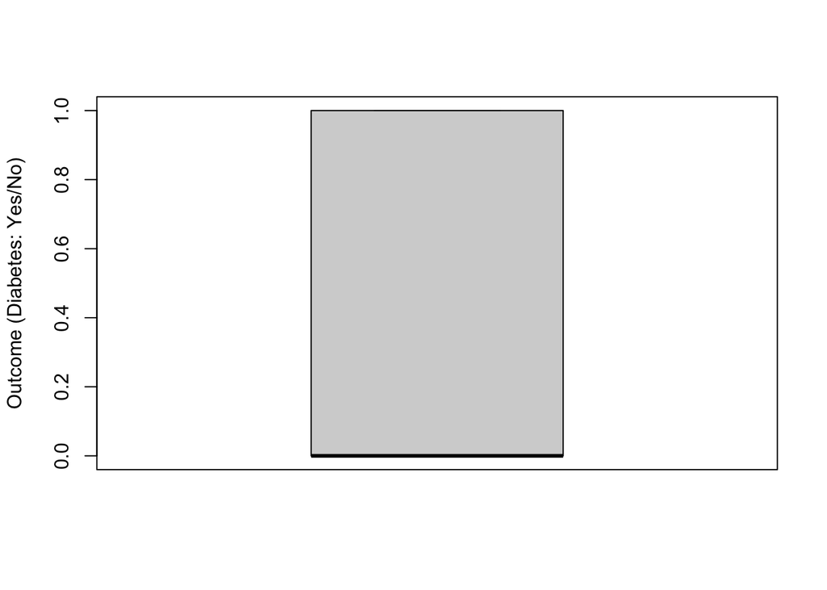

```r
boxplot(diabetes_data$Outcome, ylab = "Outcome (Diabetes: Yes/No)")
```

```r
# Summaries of the outcome and Diabetes Pedigree Function
summary(diabetes_data$Outcome)
```

```
##    Min. 1st Qu.  Median    Mean 3rd Qu.    Max.
##   0.000   0.000   0.000   0.349   1.000   1.000
```

```r
summary(diabetes_data$DiabetesPedigreeFunction)
```

```
##    Min. 1st Qu.  Median    Mean 3rd Qu.    Max.
##  0.0780  0.2437  0.3725  0.4719  0.6262  2.4200
```

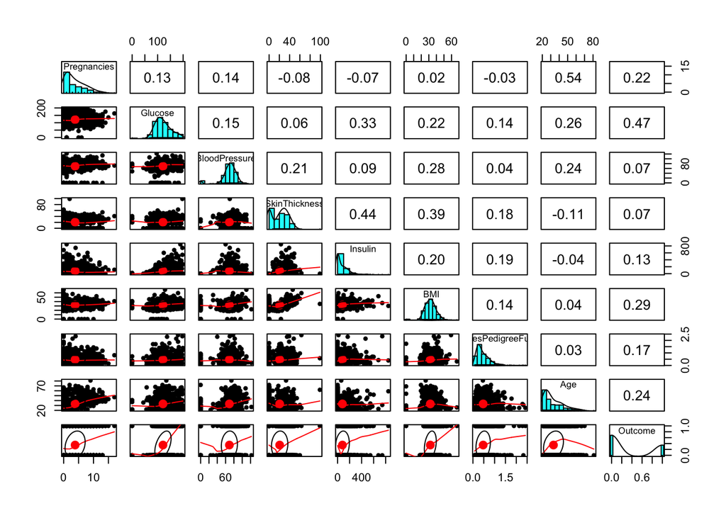

```r
# Pairwise scatter plots for the entire dataset
pairs.panels(diabetes_data)
```

[figure not shown]

```r
# Selecting key parameters for scatter plots
important_param <- diabetes_data %>%
  select(Glucose, BloodPressure, Age, Outcome)
pairs.panels(important_param)

# Glucose vs. Outcome
p <- ggplot(diabetes_data, aes(x=Glucose, y=Outcome)) +
    geom_point(shape=1) +
    geom_smooth(method=lm , color="red", se=TRUE) +
    xlab("Glucose Level") +
    ylab("Outcome (Diabetes: Yes/No)")
ggMarginal(p, type="histogram")
```

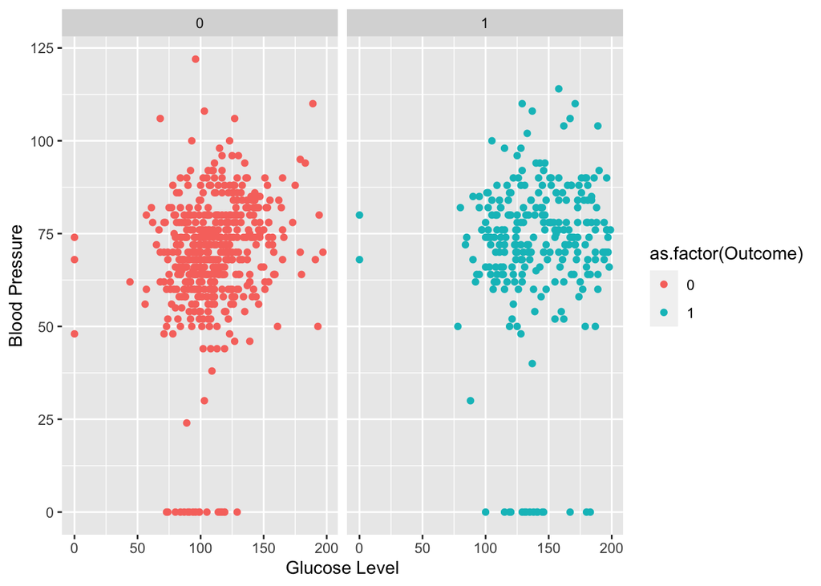

```r
# facet plot based on Outcome
ggplot(data = diabetes_data) +
  geom_point(mapping = aes(x = Glucose, y = BloodPressure, color = as.factor(Outcome))) +
  facet_wrap(~ Outcome) +
  xlab("Glucose Level") +
  ylab("Blood Pressure")
```

//Verifying the Data Quality The Pima Indians Diabetes Database is of notable quality. However, certain features contain zero values, which in the context of the dataset might imply missing or unrecorded values rather than actual zero measurements. The dataset offers 768 observations across 8 health-related features, with ‘Outcome’ being the primary target for prediction.

////PHASE THREE: DATA PREPARATION This phase focuses on the adjustments required to enhance the dataset’s utility for modeling.

//Selection of Data All features within the Pima Indians Diabetes Database are considered relevant due to their potential health implications. Each feature will be reviewed, ensuring its appropriate contribution to the predictive model.

//Clean Data A significant cleaning action involved addressing the zero values present in columns such as ‘Glucose’, ‘BloodPressure’, ‘SkinThickness’, ‘Insulin’, and ‘BMI’. Given the medical context, these zero values may be placeholders for missing or unrecorded data, rather than true zero measurements.

//Construct Data No additional features or variables were derived from the existing dataset. However, zero values in certain features were addressed by replacing them with a suitable statistical measure, such as the median or mean, to ensure they accurately represent the data distribution.

//Integrate Data There was no requirement for additional data sources or integrations, as the dataset is comprehensive for the project’s objectives.

//Format Data The key formatting action involved imputing zero values in specific features. These zero entries were substituted with the feature’s median value, ensuring a more accurate representation without introducing undue bias.

```r
# Identifying potential missing values in key columns
cols_with_potential_missing <- c("Glucose", "BloodPressure", "BMI", "SkinThickness", "Insulin")
missing_data <- lapply(cols_with_potential_missing, function(col) {
  sum(diabetes_data[[col]] == 0)
})
names(missing_data) <- cols_with_potential_missing
missing_data
```

```
## $Glucose
## [1] 5
##
## $BloodPressure
## [1] 35
##
## $BMI
## [1] 11
##
## $SkinThickness
## [1] 227
##
## $Insulin
## [1] 374
```

```r
# Replace zeros with median for specific columns
for (col in cols_with_potential_missing) {
  median_val <- median(diabetes_data[[col]][diabetes_data[[col]] > 0])
  diabetes_data[[col]][diabetes_data[[col]] == 0] <- median_val
}

# Displaying the updated summary for these columns
summary(diabetes_data[cols_with_potential_missing])
```

```
##     Glucose       BloodPressure         BMI        SkinThickness
##  Min.   : 44.00   Min.   : 24.00   Min.   :18.20   Min.   : 7.00
##  1st Qu.: 99.75   1st Qu.: 64.00   1st Qu.:27.50   1st Qu.:25.00
##  Median :117.00   Median : 72.00   Median :32.30   Median :29.00
##  Mean   :121.66   Mean   : 72.39   Mean   :32.46   Mean   :29.11
##  3rd Qu.:140.25   3rd Qu.: 80.00   3rd Qu.:36.60   3rd Qu.:32.00
##  Max.   :199.00   Max.   :122.00   Max.   :67.10   Max.   :99.00
##     Insulin
##  Min.   : 14.0
##  1st Qu.:121.5
##  Median :125.0
##  Mean   :140.7
##  3rd Qu.:127.2
##  Max.   :846.0
```

////PHASE FOUR: MODELLING

//Assess the model:  
After the rigorous modeling phase, it was time to test their capabilities on the validation set. This not only revealed their accuracy but also other vital metrics that judge a model’s efficacy. In cases of underperformance, I was poised to recalibrate, be it through parameter adjustments, revisiting feature inclusion, or augmenting the training data, ensuring my models were nothing short of the best.

```r
# Random Forest for Feature Importance
set.seed(100)
rf_model <- randomForest(Outcome ~ ., data=diabetes_data, importance=TRUE)
importance(rf_model)  # To show the importance of each variable
```

```
##                             %IncMSE IncNodePurity
## Pregnancies              11.1253599      12.39937
## Glucose                  47.8229429      41.49828
## BloodPressure            -0.2017759      12.41552
## SkinThickness             2.0261976      10.87625
## Insulin                  12.3148327      13.89401
## BMI                      22.7010772      25.23774
## DiabetesPedigreeFunction  6.4938333      19.07512
## Age                      19.4407734      21.70780
```

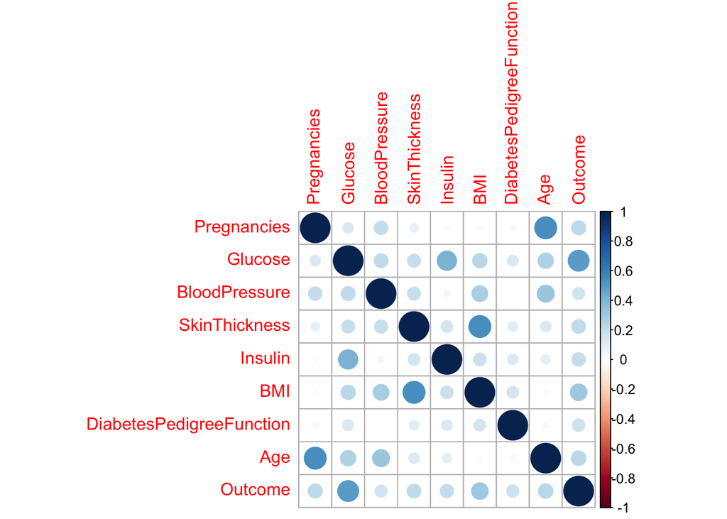

```r
# Correlation Analysis
cor_matrix <- cor(diabetes_data[, sapply(diabetes_data, is.numeric)])
corrplot(cor_matrix, method = "circle")
```

The output provided is the importance score for each predictor variable in predicting diabetes. Higher %IncMSE indicates higher importance.

- Glucose seems to be the most important predictor, followed by BMI, Age, Insulin, and Pregnancies.
- The BloodPressure variable, interestingly, has a negative %IncMSE, suggesting that randomly permuting its values can lead to a model with slightly better accuracy, meaning it might not be a significant predictor in this context.

```r
## KNN
# Selecting relevant numeric predictors and outcome
diabetes_num_df <- diabetes_data %>%
  select(Pregnancies, Glucose, BloodPressure, SkinThickness,
         Insulin, BMI, DiabetesPedigreeFunction, Age, Outcome)

# Normalize the data
normalize <- function(x) {
  return((x - min(x)) / (max(x) - min(x)))
}

# Applying the normalization function
diabetes_num_df_n <- as.data.frame(lapply(diabetes_num_df[,1:8], normalize))

# Splitting the dataset randomly
smp_size <- floor(0.75 * nrow(diabetes_num_df_n))
set.seed(123)
train_ind <- sample(seq_len(nrow(diabetes_num_df_n)), size = smp_size)

diabetes_train <- diabetes_num_df_n[train_ind, ]
diabetes_test <- diabetes_num_df_n[-train_ind, ]

# Assigning labels
diabetes_train_labels <- diabetes_num_df[train_ind, 9]
diabetes_test_labels <- diabetes_num_df[-train_ind, 9]

# Verifying the dimensions of training data
dim(diabetes_train)
```

```
## [1] 576   8
```

```r
# Applying KNN
diabetes_test_pred <- knn(train = diabetes_train,
                          test = diabetes_test,
                          cl = diabetes_train_labels,
                          k = 3)

# Evaluating the model
confusion_matrix <- table(diabetes_test_labels, diabetes_test_pred)
print(confusion_matrix)
```

```
##                     diabetes_test_pred
## diabetes_test_labels   0   1
##                    0 109  16
##                    1  33  34
```

```r
# For optimization with caret and more details, you can extend this further.
```

```r
# Calculating evaluation metrics from the confusion matrix

total_samples <- sum(confusion_matrix)
accuracy <- (confusion_matrix[1,1] + confusion_matrix[2,2]) / total_samples
sensitivity <- confusion_matrix[2,2] / (confusion_matrix[2,2] + confusion_matrix[2,1]) # Recall
specificity <- confusion_matrix[1,1] / (confusion_matrix[1,1] + confusion_matrix[1,2])
precision <- confusion_matrix[2,2] / (confusion_matrix[2,2] + confusion_matrix[1,2])
f1_score <- 2 * ((precision * sensitivity) / (precision + sensitivity))

cat("Accuracy:", accuracy, "\n")
```

```
## Accuracy: 0.7447917
```

```r
cat("Sensitivity (Recall):", sensitivity, "\n")
```

```
## Sensitivity (Recall): 0.5074627
```

```r
cat("Specificity:", specificity, "\n")
```

```
## Specificity: 0.872
```

```r
cat("Precision:", precision, "\n")
```

```
## Precision: 0.68
```

```r
cat("F1 Score:", f1_score, "\n")
```

```
## F1 Score: 0.5811966
```

The model is reasonably good at identifying negative cases (as indicated by the high specificity) but has some difficulty in correctly classifying positive cases, as shown by the sensitivity value. Depending on the use case of the model, I want to focus on increasing the sensitivity (recall) without sacrificing too much precision. For instance, if it’s crucial to identify all possible diabetes cases (even at the risk of having a few false positives), then optimizing for sensitivity would be a priority.

//Using 5-fold cross validation

```r
# Split the dataset

diabetes_num_df$Outcome <- as.factor(diabetes_num_df$Outcome)

smp_size <- floor(0.75 * nrow(diabetes_num_df))
set.seed(123)
train_ind <- sample(seq_len(nrow(diabetes_num_df)), size = smp_size)

diabetes_train <- diabetes_num_df[train_ind, ]
diabetes_test <- diabetes_num_df[-train_ind, ]

# Define training control
trCtrl <- trainControl(method = "cv", number = 5)

# Apply KNN with caret and pre-processing
set.seed(123)
knn_model_caret <- train(Outcome ~ ., data = diabetes_train,
                         method = "knn",
                         trControl = trCtrl,
                         preProcess = c("center", "scale"),
                         tuneLength = 10)

# Predict on test data
diabetes_test_pred_caret <- predict(knn_model_caret, newdata = diabetes_test)
confusionMatrix(diabetes_test_pred_caret, diabetes_test$Outcome)
```

```
## Confusion Matrix and Statistics
##
##           Reference
## Prediction   0   1
##          0 109  33
##          1  16  34
##
##                Accuracy : 0.7448
##                  95% CI : (0.677, 0.8048)
##     No Information Rate : 0.651
##     P-Value [Acc > NIR] : 0.003401
##
##                   Kappa : 0.4032
##
##  Mcnemar's Test P-Value : 0.022271
##
##             Sensitivity : 0.8720
##             Specificity : 0.5075
##          Pos Pred Value : 0.7676
##          Neg Pred Value : 0.6800
##              Prevalence : 0.6510
##          Detection Rate : 0.5677
##    Detection Prevalence : 0.7396
##       Balanced Accuracy : 0.6897
##
##        'Positive' Class : 0
##
```

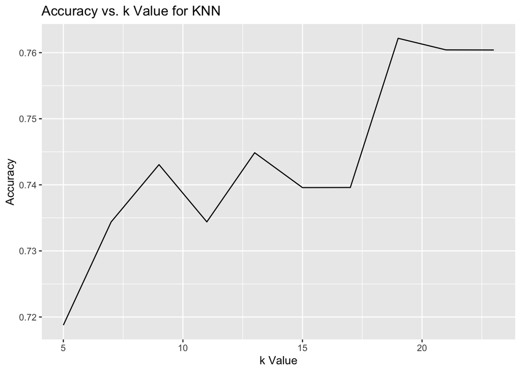

```r
# Visualize accuracy vs. different k values
knn_results <- knn_model_caret$results
ggplot(data = knn_results, aes(x = k, y = Accuracy)) +
  geom_line() +
  ggtitle("Accuracy vs. k Value for KNN") +
  xlab("k Value") +
  ylab("Accuracy")
```

// 10 fold cross validation

```r
# Identify the Best k Value:
# By visually inspecting the plot, you can find the k-value that gives the highest accuracy.
optimal_k <- knn_results$k[which.max(knn_results$Accuracy)]

# Train KNN model using the optimal k-value.
optimal_knn_pred <- knn(train = diabetes_train[-9],
                        test = diabetes_test[-9],
                        cl = diabetes_train$Outcome,
                        k = optimal_k)

# Evaluate the New Model:
# Use the confusionMatrix function from the caret package to evaluate performance.
optimal_knn_results <- confusionMatrix(optimal_knn_pred, diabetes_test$Outcome)
print(optimal_knn_results)
```

```
## Confusion Matrix and Statistics
##
##           Reference
## Prediction   0   1
##          0 108  35
##          1  17  32
##
##                Accuracy : 0.7292
##                  95% CI : (0.6605, 0.7906)
##     No Information Rate : 0.651
##     P-Value [Acc > NIR] : 0.01287
##
##                   Kappa : 0.3643
##
##  Mcnemar's Test P-Value : 0.01840
##
##             Sensitivity : 0.8640
##             Specificity : 0.4776
##          Pos Pred Value : 0.7552
##          Neg Pred Value : 0.6531
##              Prevalence : 0.6510
##          Detection Rate : 0.5625
##    Detection Prevalence : 0.7448
##       Balanced Accuracy : 0.6708
##
##        'Positive' Class : 0
##
```

```r
# Cross-Validation:
# Implementing k-fold cross-validation using the caret package for the KNN model.
control <- trainControl(method = "cv", number = 10) # 10-fold CV
cv_model <- train(Outcome ~ ., data = diabetes_train, method = "knn",
                 tuneGrid = data.frame(k = optimal_k), trControl = control)
print(cv_model)
```

```
## k-Nearest Neighbors
##
## 576 samples
##   8 predictor
##   2 classes: '0', '1'
##
## No pre-processing
## Resampling: Cross-Validated (10 fold)
## Summary of sample sizes: 519, 518, 519, 518, 518, 519, ...
## Resampling results:
##
##   Accuracy   Kappa
##   0.7449604  0.4066034
##
## Tuning parameter 'k' was held constant at a value of 19
```